# Fifa19 Machine Learning - Business Analytics

Babak Barghi, Will Rains

6/11/2021

```r
fifa_exam <- readRDS("fifa_exam.RDS")

finalDS <- fifa_exam

glimpse(finalDS)
```

```
## Rows: 18,147
## Columns: 40
## $ ID              <dbl> 158023, 20801, 190871, 193080, 192985, 183277, 177003,~
## $ Age             <dbl> 31, 33, 26, 27, 27, 27, 32, 31, 32, 25, 29, 28, 32, 32~
## $ Weight          <dbl> 159, 183, 150, 168, 154, 163, 146, 190, 181, 192, 176,~
## $ Height          <dbl> 170.18, 187.96, 175.26, 193.04, 180.34, 172.72, 172.72~
## $ Position        <chr> "RF", "ST", "LW", "GK", "RCM", "LF", "RCM", "RS", "RCB~
## $ Crossing        <dbl> 84, 84, 79, 17, 93, 81, 86, 77, 66, 13, 62, 88, 55, 84~
## $ Finishing       <dbl> 95, 94, 87, 13, 82, 84, 72, 93, 60, 11, 91, 76, 42, 76~
## $ HeadingAccuracy <dbl> 70, 89, 62, 21, 55, 61, 55, 77, 91, 15, 85, 54, 92, 54~
## $ ShortPassing    <dbl> 90, 81, 84, 50, 92, 89, 93, 82, 78, 29, 83, 92, 79, 93~
## $ Volleys         <dbl> 86, 87, 84, 13, 82, 80, 76, 88, 66, 13, 89, 82, 47, 82~
## $ Dribbling       <dbl> 97, 88, 96, 18, 86, 95, 90, 87, 63, 12, 85, 81, 53, 89~
## $ Curve           <dbl> 93, 81, 88, 21, 85, 83, 85, 86, 74, 13, 77, 86, 49, 82~
## $ FKAccuracy      <dbl> 94, 76, 87, 19, 83, 79, 78, 84, 72, 14, 86, 84, 51, 77~
```

[output cut: 27 more lines]

###Calculate Ratings Overall

##Based on https://fifauteam.com/player-ratings-guide-fifa-19/

```r
finalDS <- finalDS %>%
  mutate(Overall = case_when(
    Position=="ST" | Position=="RS" | Position=="LS" ~ Finishing*.2+Positioning*.12+HeadingAccuracy*.10+ShotPower*.10+Reactions*.10+Dribbling*.08+BallControl*.08+Volleys*.05+LongShots*.05+Acceleration*.05+SprintSpeed*.04+Strength*.03,
    Position=="RF" | Position=="CF" | Position=="LF" | Position =="RW" | Position =="LW" | Position=="RM" | Position=="LM" ~ Finishing*.12+Positioning*.12+Dribbling*.11+BallControl*.11+ShotPower*.10+LongShots*.10+Reactions*.10+ShortPassing*.06+HeadingAccuracy*.05+Vision*.05+Acceleration*.04+SprintSpeed*.04,
    Position=="GK" ~ GKDiving*.24+GKHandling*.22+GKKicking*.04+GKPositioning*.22+GKReflexes*.22+Reactions*.06,
    Position=="CB" |  Position=="RCB" |  Position=="LCB" ~ Marking*.15+StandingTackle*.15+SlidingTackle*.15+HeadingAccuracy*.10+Strength*.10+Aggression*.08+Interceptions*.08+ShortPassing*.05+BallControl*.05+Reactions*.05+Jumping*.04,
    Position=="RB" | Position=="LB" | Position=="RWB" | Position=="LWB" ~ Marking*.10+StandingTackle*.12+SlidingTackle*.13+HeadingAccuracy*.07+Stamina*.08+Aggression*.05+Interceptions*.1+ShortPassing*.07+SprintSpeed*.05+BallControl*.08+Reactions*.05+Agility*.03,
    Position=="CDM" | Position=="CM" | Position=="CAM" | Position=="RCM" | Position=="LCM" | Position=="LDM" | Position=="RDM" | Position=="LAM" | Position=="RAM"  ~ ShortPassing*.15+LongPassing*.13+Vision*.12+BallControl*.10+Dribbling*.09+Reactions*.08+Interceptions*.08+Positioning*.08+StandingTackle*.06+Stamina*.06+LongShots*.05
    )
  )
```

Add new variable for categorizing the Position into 4 parts as follow.

```r
finalDS <- finalDS %>%
  mutate(Position_new = case_when(
    Position=="ST" | Position=="RS" | Position=="LS" | Position=="RF" | Position=="CF" | Position=="LF" ~ "Striker",
    Position =="CDM" | Position =="CM" | Position=="CAM" | Position=="LCM" | Position =="LAM" | Position =="LW" | Position=="LM" | Position=="LDM"  | Position =="RCM" | Position=="RAM" | Position=="RW"  | Position=="RM" | Position=="RDM" ~ "Midfielder",
    Position=="GK" ~ "Goalkeeper",
    Position=="CB" |  Position=="RCB" |  Position=="LCB" | Position=="RB" | Position=="LB" | Position=="RWB" | Position=="LWB" ~ "Defender"
    )
  )
```

```r
skim(finalDS)
```

Data summary

| Name | finalDS |
| --- | --- |
| Number of rows | 18147 |
| Number of columns | 42 |
| _______________________ |  |
| Column type frequency: |  |
| character | 2 |
| numeric | 40 |
| ________________________ |  |
| Group variables | None |

**Variable type: character**

| skim_variable | n_missing | complete_rate | min | max | empty | n_unique | whitespace |
| --- | --- | --- | --- | --- | --- | --- | --- |
| Position | 0 | 1 | 2 | 3 | 0 | 27 | 0 |
| Position_new | 0 | 1 | 7 | 10 | 0 | 4 | 0 |

**Variable type: numeric**

| skim_variable | n_missing | complete_rate | mean | sd | p0 | p25 | p50 | p75 | p100 | hist |
| --- | --- | --- | --- | --- | --- | --- | --- | --- | --- | --- |
| ID | 0 | 1 | 214279.82 | 29970.32 | 16.00 | 200305.50 | 221740.00 | 236512.50 | 246620.00 | ▁▁▁▂▇ |
| Age | 0 | 1 | 25.12 | 4.67 | 16.00 | 21.00 | 25.00 | 28.00 | 45.00 | ▅▇▅▁▁ |
| Weight | 0 | 1 | 165.98 | 15.59 | 110.00 | 154.00 | 165.00 | 176.00 | 243.00 | ▁▇▇▂▁ |
| Height | 0 | 1 | 181.26 | 6.73 | 154.94 | 175.26 | 180.34 | 185.42 | 205.74 | ▁▃▇▃▁ |
| Crossing | 0 | 1 | 49.74 | 18.36 | 5.00 | 38.00 | 54.00 | 64.00 | 93.00 | ▂▃▆▇▁ |
| Finishing | 0 | 1 | 45.55 | 19.53 | 2.00 | 30.00 | 49.00 | 62.00 | 95.00 | ▃▆▇▇▁ |
| HeadingAccuracy | 0 | 1 | 52.30 | 17.38 | 4.00 | 44.00 | 56.00 | 64.00 | 94.00 | ▂▂▇▇▁ |
| ShortPassing | 0 | 1 | 58.70 | 14.70 | 7.00 | 54.00 | 62.00 | 68.00 | 93.00 | ▁▁▃▇▁ |
| Volleys | 0 | 1 | 42.91 | 17.70 | 4.00 | 30.00 | 44.00 | 57.00 | 90.00 | ▃▆▇▆▁ |
| Dribbling | 0 | 1 | 55.38 | 18.91 | 4.00 | 49.00 | 61.00 | 68.00 | 97.00 | ▂▁▅▇▁ |
| Curve | 0 | 1 | 47.18 | 18.40 | 6.00 | 34.00 | 48.00 | 62.00 | 94.00 | ▃▆▇▇▁ |
| FKAccuracy | 0 | 1 | 42.87 | 17.48 | 3.00 | 31.00 | 41.00 | 57.00 | 94.00 | ▃▇▇▅▁ |
| LongPassing | 0 | 1 | 52.72 | 15.33 | 9.00 | 43.00 | 56.00 | 64.00 | 93.00 | ▂▃▇▇▁ |
| BallControl | 0 | 1 | 58.37 | 16.69 | 5.00 | 54.00 | 63.00 | 69.00 | 96.00 | ▁▁▃▇▁ |
| Acceleration | 0 | 1 | 64.61 | 14.93 | 12.00 | 57.00 | 67.00 | 75.00 | 97.00 | ▁▂▃▇▂ |
| SprintSpeed | 0 | 1 | 64.73 | 14.65 | 12.00 | 57.00 | 67.00 | 75.00 | 96.00 | ▁▂▃▇▂ |
| Agility | 0 | 1 | 63.50 | 14.77 | 14.00 | 55.00 | 66.00 | 74.00 | 96.00 | ▁▂▅▇▂ |
| Reactions | 0 | 1 | 61.84 | 9.01 | 21.00 | 56.00 | 62.00 | 68.00 | 96.00 | ▁▂▇▅▁ |
| Balance | 0 | 1 | 63.96 | 14.14 | 16.00 | 56.00 | 66.00 | 74.00 | 96.00 | ▁▂▆▇▂ |
| ShotPower | 0 | 1 | 55.47 | 17.24 | 2.00 | 45.00 | 59.00 | 68.00 | 95.00 | ▁▂▅▇▁ |
| Jumping | 0 | 1 | 65.09 | 11.82 | 15.00 | 58.00 | 66.00 | 73.00 | 95.00 | ▁▁▆▇▂ |
| Stamina | 0 | 1 | 63.22 | 15.90 | 12.00 | 56.00 | 66.00 | 74.00 | 96.00 | ▁▂▃▇▂ |
| Strength | 0 | 1 | 65.32 | 12.55 | 17.00 | 58.00 | 67.00 | 74.00 | 97.00 | ▁▂▆▇▂ |
| LongShots | 0 | 1 | 47.11 | 19.26 | 3.00 | 33.00 | 51.00 | 62.00 | 94.00 | ▃▅▇▇▁ |
| Aggression | 0 | 1 | 55.88 | 17.37 | 11.00 | 44.00 | 59.00 | 69.00 | 95.00 | ▂▃▇▇▂ |
| Interceptions | 0 | 1 | 46.70 | 20.70 | 3.00 | 26.00 | 52.00 | 64.00 | 92.00 | ▃▅▅▇▁ |
| Positioning | 0 | 1 | 49.96 | 19.53 | 2.00 | 38.00 | 55.00 | 64.00 | 95.00 | ▂▃▆▇▁ |
| Vision | 0 | 1 | 53.41 | 14.15 | 10.00 | 44.00 | 55.00 | 64.00 | 94.00 | ▁▅▇▆▁ |
| Penalties | 0 | 1 | 48.55 | 15.70 | 5.00 | 39.00 | 49.00 | 60.00 | 92.00 | ▂▃▇▆▁ |
| Composure | 0 | 1 | 58.65 | 11.44 | 3.00 | 51.00 | 60.00 | 67.00 | 96.00 | ▁▁▆▇▁ |
| Marking | 0 | 1 | 47.29 | 19.90 | 3.00 | 30.00 | 53.00 | 64.00 | 94.00 | ▃▅▅▇▁ |
| StandingTackle | 0 | 1 | 47.70 | 21.66 | 2.00 | 27.00 | 55.00 | 66.00 | 93.00 | ▃▃▃▇▁ |
| SlidingTackle | 0 | 1 | 45.67 | 21.29 | 3.00 | 24.00 | 52.00 | 64.00 | 91.00 | ▅▃▃▇▁ |
| GKDiving | 0 | 1 | 16.62 | 17.70 | 1.00 | 8.00 | 11.00 | 14.00 | 90.00 | ▇▁▁▁▁ |
| GKHandling | 0 | 1 | 16.39 | 16.91 | 1.00 | 8.00 | 11.00 | 14.00 | 92.00 | ▇▁▁▁▁ |
| GKKicking | 0 | 1 | 16.23 | 16.50 | 1.00 | 8.00 | 11.00 | 14.00 | 91.00 | ▇▁▁▁▁ |
| GKPositioning | 0 | 1 | 16.39 | 17.04 | 1.00 | 8.00 | 11.00 | 14.00 | 90.00 | ▇▁▁▁▁ |
| GKReflexes | 0 | 1 | 16.71 | 17.96 | 1.00 | 8.00 | 11.00 | 14.00 | 94.00 | ▇▁▁▁▁ |
| Value | 0 | 1 | 2417.73 | 5602.83 | 0.00 | 300.00 | 675.00 | 2000.00 | 118500.00 | ▇▁▁▁▁ |
| Overall | 0 | 1 | 63.55 | 7.19 | 38.20 | 58.70 | 63.47 | 68.36 | 92.22 | ▁▅▇▂▁ |

```r
finalDS %>%
  count(Position_new,
        sort = TRUE)
```

```
## # A tibble: 4 x 2
##   Position_new     n
##   <chr>        <int>
## 1 Midfielder    7589
## 2 Defender      5866
## 3 Striker       2667
## 4 Goalkeeper    2025
```

4 levels of Positions, highest number of Positions are for Midfielders and Defenders.

Now, we evaluate the values.

```r
###Testing ranges to see where the zeroes start for value. Weighing a decision to filter out zeroes for the machine learning task

finalDS %>% filter(Value==0) %>% summarise("Number of players with Zero Value"=n())
```

```
## # A tibble: 1 x 1
##   `Number of players with Zero Value`
##                                 <int>
## 1                                 240
```

```r
finalDS %>% filter(Value==0) %>% filter(Overall<=79 & Overall>74) %>% select(Value,Overall,Age) %>% arrange(desc(Overall))
```

```
## # A tibble: 8 x 3
##   Value Overall   Age
##   <dbl>   <dbl> <dbl>
## 1     0    78.1    26
## 2     0    77.3    40
## 3     0    76.7    29
## 4     0    76.4    24
## 5     0    75.9    41
## 6     0    75.8    30
## 7     0    75.4    29
## 8     0    74.1    28
```

```r
finalDS %>% filter(Value==0) %>% filter(Overall<=79 & Overall>74) %>% select(Value,Overall,Age) %>% arrange(desc(Overall)) %>% summarise("Average Age" = mean(Age))
```

```
## # A tibble: 1 x 1
##   `Average Age`
##           <dbl>
## 1          30.9
```

```r
finalDS %>% summarise("Average Age" = mean(Age))
```

```
## # A tibble: 1 x 1
##   `Average Age`
##           <dbl>
## 1          25.1
```

```r
finalDS %>% filter(Value==0) %>% filter(Overall<=74 & Overall>69) %>% select(Value,Overall) %>% arrange(desc(Overall))
```

```
## # A tibble: 48 x 2
##    Value Overall
##    <dbl>   <dbl>
##  1     0    74.0
##  2     0    73.9
##  3     0    73.7
##  4     0    73.5
##  5     0    73.4
##  6     0    73.4
##  7     0    73.4
##  8     0    73.3
##  9     0    73.3
## 10     0    73.1
## # ... with 38 more rows
```

```r
finalDS %>% filter(Value==0) %>% filter(Overall<=69 & Overall>50) %>% select(Value,Overall) %>% arrange(desc(Overall))
```

```
## # A tibble: 180 x 2
##    Value Overall
##    <dbl>   <dbl>
##  1     0    69.0
##  2     0    68.9
##  3     0    68.9
##  4     0    68.8
##  5     0    68.7
##  6     0    68.6
##  7     0    68.6
##  8     0    68.5
##  9     0    68.5
## 10     0    68.4
## # ... with 170 more rows
```

```r
finalDS %>% filter(Overall<79 & Overall>74) %>% select(Value,Overall) %>% arrange(desc(Overall))
```

```
## # A tibble: 980 x 2
##    Value Overall
##    <dbl>   <dbl>
##  1 13000    79.0
##  2 15500    79.0
##  3 34500    78.9
##  4 10500    78.9
##  5 22000    78.9
##  6 12000    78.9
##  7 11000    78.9
##  8 13000    78.9
##  9 18000    78.9
## 10 17500    78.9
## # ... with 970 more rows
```

```r
finalDS %>% filter(Overall<79 & Overall>74) %>% select(Value,Overall) %>% arrange(desc(Overall)) %>%
  summarise(mean(Value))
```

```
## # A tibble: 1 x 1
##   `mean(Value)`
##           <dbl>
## 1        10406.
```

```r
finalDS %>% filter(Overall<69 & Overall>50) %>% select(Value,Overall) %>% arrange(desc(Overall)) %>%
  summarise(mean(Value))
```

```
## # A tibble: 1 x 1
##   `mean(Value)`
##           <dbl>
## 1          834.
```

```r
#remove zero values (outliers)
baseDS <- finalDS %>% filter(Value != 0)
```

```r
fifa_model <- finalDS %>% filter(Value != 0) %>% select(-ID, -Position, -Overall, -Position_new)
```

Now we will make a few plots to get a sense of age x value and overall correlation between variables.

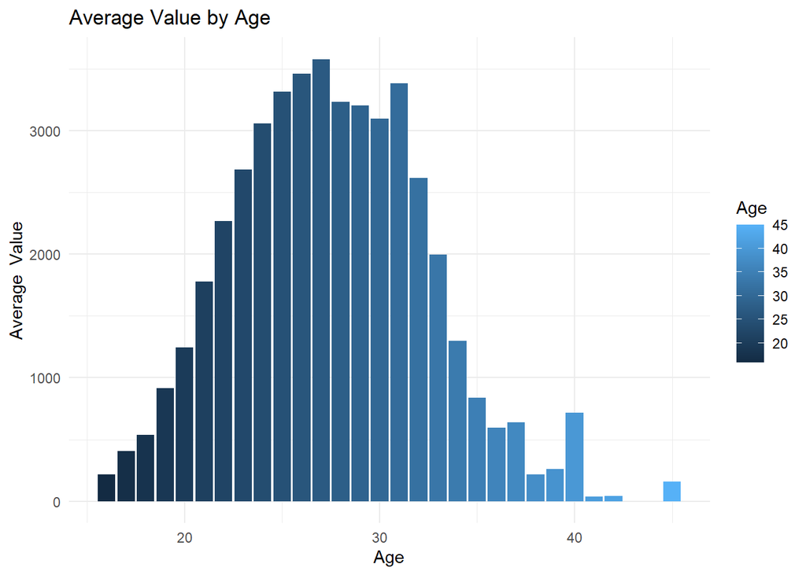

```r
#What age has the peak value?


baseDS %>% select(Age,Value) %>%
  group_by(Age) %>%
  summarise(AvgValue=mean(Value)) %>%
  ggplot(aes(x=Age,y=AvgValue)) +
  geom_bar(stat="identity",aes(fill=Age)) +
  theme_minimal() +
  labs(y="Average  Value", title = "Average Value by Age")
```

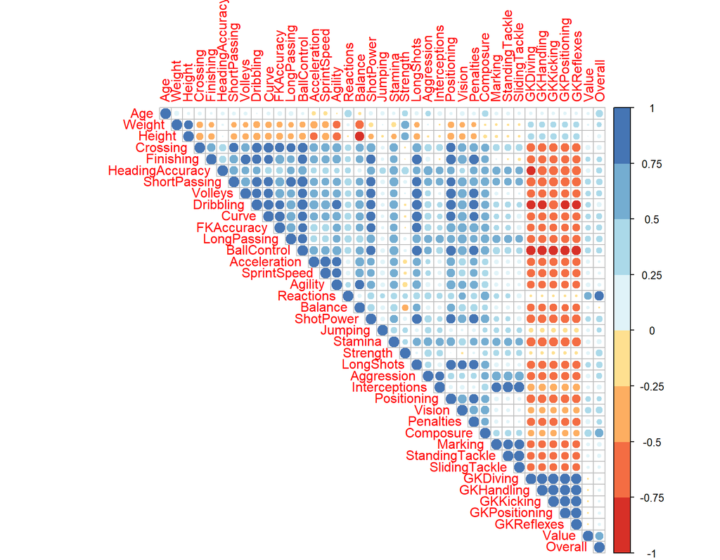

```r
Fifa_data_numonly <- finalDS %>%
  select_if(is_numeric) %>%
  select(-ID)

acorr <-cor(Fifa_data_numonly)
corrplot(acorr, type="upper", na.label = "N",
         col=brewer.pal(n=8, name="RdYlBu"))
```

From the corplot we see that Composure, Reaction & Overall have significant correlation with Value.

PART 1 Classification and Predicting Position

Now we will repeat this process for Classification and Predicting Position

```r
#Set data set based on Classification
fifa_class <- finalDS %>% select(-ID, -Overall, -Position)

#We use initial_split to build train and test sets:
set.seed(42)
fifaSplit <- initial_split(fifa_class, prob = 0.8)

fifaTrain <- training(fifaSplit)
fifaTest <- testing(fifaSplit)


fifaRecipe2 <- fifaTrain %>%
  recipe(Position_new ~ .) %>%
  step_mutate(Position_new = as.factor(Position_new)) %>%
  step_center(all_numeric(),-all_outcomes()) %>%
  step_scale(all_numeric(),-all_outcomes()) %>%
  prep()

fifaTrain_proc2 <- bake(fifaRecipe2, new_data = fifaTrain)
fiftest_proc2 <- bake(fifaRecipe2, new_data = fifaTest)

#-------KNN
knn_spec2 <- nearest_neighbor() %>%
  set_engine("kknn") %>%
  set_mode("classification")

knn_fit2 <- knn_spec2 %>%
  fit(Position_new ~ .,
      data=fifaTrain_proc2)

knn_fit2
```

```
## parsnip model object
##
## Fit time:  5.7s
##
## Call:
## kknn::train.kknn(formula = Position_new ~ ., data = data, ks = min_rows(5,     data, 5))
##
## Type of response variable: nominal
## Minimal misclassification: 0.1477481
## Best kernel: optimal
## Best k: 5
```

```r
#-------Tree
tree_spec2 <- decision_tree() %>%
  set_engine("rpart") %>%
  set_mode("classification") %>%
  translate()

tree_fit2 <- tree_spec2 %>%
  fit(Position_new ~ .,
      data=fifaTrain_proc2)

tree_fit2
```

```
## parsnip model object
##
## Fit time:  700ms
## n= 13611
##
## node), split, n, loss, yval, (yprob)
##       * denotes terminal node
##
##   1) root 13611 7966 Midfielder (0.3242230549 0.1124825509 0.4147380795 0.1485563147)
##     2) GKDiving>=1.369347 1531    0 Goalkeeper (0.0000000000 1.0000000000 0.0000000000 0.0000000000) *
##     3) GKDiving< 1.369347 12080 6435 Midfielder (0.3653145695 0.0000000000 0.4673013245 0.1673841060)
##       6) Finishing< -0.04985809 4493 1104 Defender (0.7542844425 0.0000000000 0.2454929891 0.0002225684)
##        12) Vision< -0.5582209 2196  120 Defender (0.9453551913 0.0000000000 0.0546448087 0.0000000000) *
##        13) Vision>=-0.5582209 2297  984 Defender (0.5716151502 0.0000000000 0.4279494993 0.0004353505)
##          26) SlidingTackle>=0.6059678 1618  450 Defender (0.7218788628 0.0000000000 0.2781211372 0.0000000000) *
##          27) SlidingTackle< 0.6059678 679  146 Midfielder (0.2135493373 0.0000000000 0.7849779087 0.0014727541) *
##       7) Finishing>=-0.04985809 7587 3045 Midfielder (0.1349677079 0.0000000000 0.5986555951 0.2663766970)
##        14) SlidingTackle>=-0.8958773 5316 1575 Midfielder (0.1922498119 0.0000000000 0.7037246050 0.1040255831)
##          28) SlidingTackle>=0.5121025 2356  967 Midfielder (0.4040747029 0.0000000000 0.5895585739 0.0063667233)
##            56) Vision< 0.5042157 861  279 Defender (0.6759581882 0.0000000000 0.3170731707 0.0069686411) *
##            57) Vision>=0.5042157 1495  379 Midfielder (0.2474916388 0.0000000000 0.7464882943 0.0060200669) *
##          29) SlidingTackle< 0.5121025 2960  608 Midfielder (0.0236486486 0.0000000000 0.7945945946 0.1817567568)
##            58) HeadingAccuracy< 0.5360233 2382  270 Midfielder (0.0251889169 0.0000000000 0.8866498741 0.0881612091) *
##            59) HeadingAccuracy>=0.5360233 578  250 Striker (0.0173010381 0.0000000000 0.4152249135 0.5674740484)
##             118) LongPassing>=0.5787501 235   71 Midfielder (0.0085106383 0.0000000000 0.6978723404 0.2936170213) *
##             119) LongPassing< 0.5787501 343   84 Striker (0.0233236152 0.0000000000 0.2215743440 0.7551020408) *
##        15) SlidingTackle< -0.8958773 2271  803 Striker (0.0008806693 0.0000000000 0.3527080581 0.6464112726)
##          30) Crossing>=0.1562768 1072  415 Midfielder (0.0018656716 0.0000000000 0.6128731343 0.3852611940)
##            60) HeadingAccuracy< 0.2482348 546   71 Midfielder (0.0018315018 0.0000000000 0.8699633700 0.1282051282) *
##            61) HeadingAccuracy>=0.2482348 526  183 Striker (0.0019011407 0.0000000000 0.3460076046 0.6520912548) *
##          31) Crossing< 0.1562768 1199  144 Striker (0.0000000000 0.0000000000 0.1201000834 0.8798999166) *
```

```r
#------Random Forest


rf_spec <- rand_forest() %>%
  set_mode("classification") %>%
  set_engine("ranger")

##Code for abandoned hyperparameter tuning. Was taking too long default settings are ok
# rf_spec <- rand_forest(
#   mtry = tune(),
#   trees = tune()
#
# ) %>%
#   set_mode("classification") %>%
#   set_engine("ranger")
#
# #get bootstrap samples to use for hyperparameter tuning
# fifa_boot <- bootstraps(fifaTrain_proc2, times = 10)
#
# rf_wf <- workflow() %>%
#   add_model(rf_spec) %>%
#   add_formula(Position_new ~ .)
#
# rf_grid <- tune_grid(
#   rf_wf,
#   resamples = fifa_boot
# )
#
#
# rf_grid


rf_fit <- rf_spec %>%
  fit(Position_new ~ .,
      data=fifaTrain_proc2)

rf_fit
```

```
## parsnip model object
##
## Fit time:  6.3s
## Ranger result
##
## Call:
##  ranger::ranger(x = maybe_data_frame(x), y = y, num.threads = 1,      verbose = FALSE, seed = sample.int(10^5, 1), probability = TRUE)
##
## Type:                             Probability estimation
## Number of trees:                  500
## Sample size:                      13611
## Number of independent variables:  38
## Mtry:                             6
## Target node size:                 10
## Variable importance mode:         none
## Splitrule:                        gini
## OOB prediction error (Brier s.):  0.07538947
```

we have assumed the default values for trees and mtry as the defaults settings for our purposes are sufficient. We have now created all of the models and fits and we will now compare the models via cross validation to choose the best one.

```r
###Folds CV
#######
#test Tree - rpart


set.seed(1234)
validation_splits <- vfold_cv(fifaTrain,v=5)

kn_wf2 <- workflow() %>%
  add_recipe(fifaRecipe2) %>%
  add_model(knn_spec2)

knn_res2 <- fit_resamples(kn_wf2,
  validation_splits ,
  control=control_resamples(save_pred = TRUE)
)
```

[output not shown]

[output not shown]

[output not shown]

[output not shown]

[output not shown]

```r
knn_res2 %>%
  collect_metrics()
```

```
## # A tibble: 2 x 6
##   .metric  .estimator  mean     n  std_err .config
##   <chr>    <chr>      <dbl> <int>    <dbl> <chr>
## 1 accuracy multiclass 0.848     5 0.00223  Preprocessor1_Model1
## 2 roc_auc  hand_till  0.969     5 0.000574 Preprocessor1_Model1
```

```r
# knn_res2 %>% unnest(.predictions)

#######
#test Tree - rpart
tree_wf2 <- workflow() %>%
  add_recipe(fifaRecipe2) %>%
  add_model(tree_spec2)

tree_res2 <- fit_resamples(tree_wf2,
                         validation_splits ,
                         control=control_resamples(save_pred = TRUE)
)

tree_res2 %>%
  collect_metrics()
```

```
## # A tibble: 2 x 6
##   .metric  .estimator  mean     n  std_err .config
##   <chr>    <chr>      <dbl> <int>    <dbl> <chr>
## 1 accuracy multiclass 0.830     5 0.00340  Preprocessor1_Model1
## 2 roc_auc  hand_till  0.957     5 0.000737 Preprocessor1_Model1
```

```r
#######
#test rf - ranger

rf_wf <- workflow() %>%
  add_recipe(fifaRecipe2) %>%
  add_model(rf_spec)

rf_res <- fit_resamples(rf_wf,
                         validation_splits ,
                         control=control_resamples(save_pred = TRUE)
)

rf_res %>%
  collect_metrics()
```

```
## # A tibble: 2 x 6
##   .metric  .estimator  mean     n  std_err .config
##   <chr>    <chr>      <dbl> <int>    <dbl> <chr>
## 1 accuracy multiclass 0.908     5 0.00145  Preprocessor1_Model1
## 2 roc_auc  hand_till  0.987     5 0.000298 Preprocessor1_Model1
```

```r
# rf_res %>% unnest(.predictions)
```

In the above comparisons you can see that all three models performed quite well, but Random Forest is the clear winner with K nearest neighbor being right behind it. These algorithms are well able using their complex and multi-faceted nature adjust for this very segmented data in a way that a simple regression is not able to. We saw the same result in that of the value model setup where random forest also won.

Now we will perform a final fit on the RF model given that we have seen it is the best performing classification model in our cross validations and test on the train and test set.

```r
fifa_fit_RF_class <- last_fit(rf_wf, split = fifaSplit)

# Show metrics on train set

class_metrics <- metric_set(accuracy, sensitivity, specificity)



# Obtain test set predictions data frame
fifa_results_RF <- fifa_fit_RF_class %>%
                 collect_predictions()
# View results
head(fifa_results_RF)
```

```
## # A tibble: 6 x 9
##   id        .pred_Defender .pred_Goalkeeper .pred_Midfielder .pred_Striker  .row
##   <chr>              <dbl>            <dbl>            <dbl>         <dbl> <int>
## 1 train/te~          0.002                0            0.423       0.575       2
## 2 train/te~          0                    0            0.515       0.485       3
## 3 train/te~          0.565                0            0.425       0.00989     9
## 4 train/te~          0                    0            0.452       0.548      16
## 5 train/te~          0                    0            0.310       0.690      24
## 6 train/te~          0.844                0            0.150       0.00567    25
## # ... with 3 more variables: .pred_class <fct>, Position_new <fct>,
## #   .config <chr>
```

```r
fifa_results_RF %>%
  class_metrics(truth = Position_new, estimate = .pred_class)
```

```
## # A tibble: 3 x 3
##   .metric  .estimator .estimate
##   <chr>    <chr>          <dbl>
## 1 accuracy multiclass     0.906
## 2 sens     macro          0.912
## 3 spec     macro          0.964
```

Now test against the test set to assess if we have overfitted.

```r
rf_wf <- workflow() %>%
  add_recipe(fifaRecipe2) %>%
  add_model(rf_spec) %>%
  fit(fifaTrain)


rf_fit %>%
  predict(new_data = fiftest_proc2) %>%
  mutate(truth=as.factor(fifaTest$Position_new)) %>%
  class_metrics(truth, estimate = .pred_class)
```

```
## # A tibble: 3 x 3
##   .metric  .estimator .estimate
##   <chr>    <chr>          <dbl>
## 1 accuracy multiclass     0.907
## 2 sens     macro          0.913
## 3 spec     macro          0.964
```

These results in the test set is quite close, thus suggesting we have done a nice job on not overfitting to the train set. Otherwise if the testing performance metrics here were much worse then it would suggest that we did over fit and performance would be worse on new data.

```r
fifa_results_RF %>%
  conf_mat(truth = Position_new, estimate = .pred_class)
```

```
##             Truth
## Prediction   Defender Goalkeeper Midfielder Striker
##   Defender       1371          0        152       1
##   Goalkeeper        0        494          0       0
##   Midfielder       82          0       1713     114
##   Striker           0          0         79     530
```

Now we will take a look at the confusion matrix for Test

```r
rf_fit %>%
  predict(new_data = fiftest_proc2) %>%
  mutate(truth=as.factor(fifaTest$Position_new)) %>%
  conf_mat(truth, estimate = .pred_class)
```

```
##             Truth
## Prediction   Defender Goalkeeper Midfielder Striker
##   Defender       1371          0        154       0
##   Goalkeeper        0        494          0       0
##   Midfielder       82          0       1715     112
##   Striker           0          0         75     533
```

Now we will take a look at ROC curve

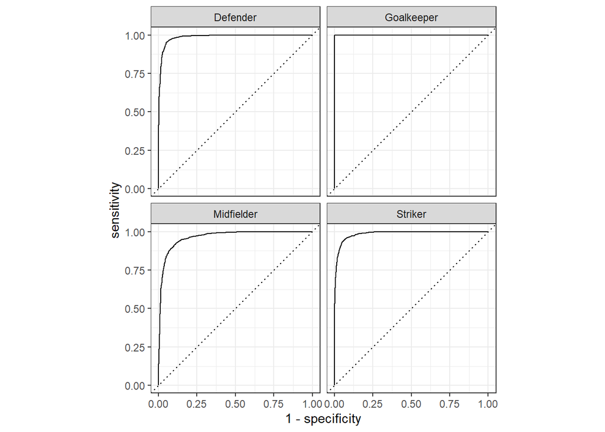

```r
rf_fifa_probs <- rf_fit %>%
  predict(new_data = fiftest_proc2, type="prob") %>%
  bind_cols(fiftest_proc2)

rf_fifa_probs %>%
  roc_curve(Position_new, .pred_Defender:.pred_Striker) %>%
  autoplot()
```

We can see that based on our results in the ROC and the conf matrix and our modeling efforts we have created a reasonably well performing machine learning model that can predict a player’s Position as defined by the new Positions that we changed in the dataset. This is valuable as the results are good and allow for people to use this model to predict with new data.

Another factor of model quality is judging that of sensitivity and specificity, if the values are under .5 then the model is worse than guessing if the values are over .5 then the model is better than guessing, as displayed in our ROC curves, the model for all position types approaches closely the corner with all important metrics above .9 indicating great model performance. The above ROC curves are plotted based off the test set performance thus this is showing that the model is not overfitted and would perform very well on new and real data

PART 2

- predicting player’s market `Value`
- Model 1

# Linear Modeling with all the variables involved

First model attempt with a simple regression model as this is the obvious choice for this type of dataset and numerical outcome.

## Data Preparation

### Data splitting

Before we build our model, we first split data into training and test set using *stratified sampling*.

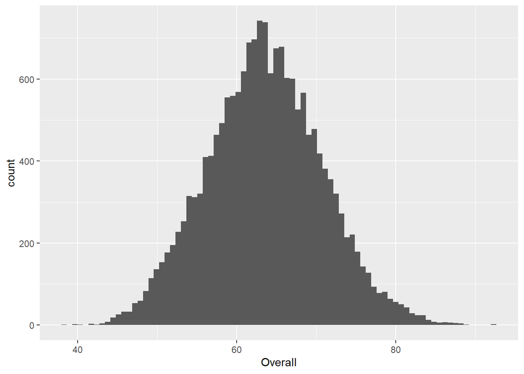

```r
baseDS %>%
  ggplot(aes(Overall)) +
  geom_histogram(bins = 80)
```

We want to ensure that the test set is representative of the various categories of Value in the whole dataset.

```r
set.seed(42)

data_split <- initial_split(fifa_model, strata = Value, prop = 0.75)

fifa_train <- training(data_split)
fifa_test <- testing(data_split)
```

### Recipes

Next, we use **recipe** function to build a set of steps for data preprocessing and feature engineering.

```r
fifa_rec <- fifa_train %>%
  recipe(Value ~ . ) %>%
  step_normalize(all_predictors())

# Show the result of our recipe
fifa_rec
```

```
## Data Recipe
##
## Inputs:
##
##       role #variables
##    outcome          1
##  predictor         37
##
## Operations:
##
## Centering and scaling for all_predictors()
```

Now we specify and then fit the models.

## Building model

```r
fifa_lm <-                       # model specification
  linear_reg() %>%               # model type
  set_engine(engine = "lm") %>%  # model engine
  set_mode("regression")         # model mode

# model specification
fifa_lm
```

```
## Linear Regression Model Specification (regression)
##
## Computational engine: lm
```

To combine the data preparation with the model building, we use the **workflows**.

## Create Workflow

```r
#define a workflow to train the model

fifa_wf <- workflow() %>%
 add_model(fifa_lm) %>%
 add_recipe(fifa_rec)
```

## Evaluate Model

We build a validation set with K-fold cross validation and perform k resamples:

```r
set.seed(12)

fifa_folds <-
 vfold_cv(fifa_train,
          strata = Value)

fifa_folds
```

```
## #  10-fold cross-validation using stratification
## # A tibble: 10 x 2
##    splits               id
##    <list>               <chr>
##  1 <split [12087/1345]> Fold01
##  2 <split [12088/1344]> Fold02
##  3 <split [12088/1344]> Fold03
##  4 <split [12088/1344]> Fold04
##  5 <split [12088/1344]> Fold05
##  6 <split [12089/1343]> Fold06
##  7 <split [12089/1343]> Fold07
##  8 <split [12090/1342]> Fold08
##  9 <split [12090/1342]> Fold09
## 10 <split [12091/1341]> Fold10
```

Now we can fit the model and collect the performance metrics with collect_metrics.

```r
fifa_resamples <-
  fifa_wf %>%
  fit_resamples(
    Value ~ .,
    resamples = fifa_folds
    )
```

[output not shown]

[output not shown]

[output not shown]

[output not shown]

[output not shown]

[output not shown]

[output not shown]

[output not shown]

[output not shown]

[output not shown]

```r
fifa_resamples %>%
    collect_metrics()
```

```
## # A tibble: 2 x 6
##   .metric .estimator     mean     n  std_err .config
##   <chr>   <chr>         <dbl> <int>    <dbl> <chr>
## 1 rmse    standard   4419.       10 208.     Preprocessor1_Model1
## 2 rsq     standard      0.392    10   0.0100 Preprocessor1_Model1
```

## Final Fit & Evaluation

Fit the best model to the training set and evaluate the test set with the function **last_fit**:

```r
fifa_fit_lm <- last_fit(fifa_wf, split = data_split)
```

```
## ! train/test split: preprocessor 1/1, model 1/1 (predictions): Unknown columns: `(Intercept)`
```

```r
# Show RMSE and RSQ
fifa_fit_lm %>%
  collect_metrics()
```

```
## # A tibble: 2 x 4
##   .metric .estimator .estimate .config
##   <chr>   <chr>          <dbl> <chr>
## 1 rmse    standard    4255.    Preprocessor1_Model1
## 2 rsq     standard       0.399 Preprocessor1_Model1
```

We can save the test set predictions by using the **collect_predictions** function. This function returns a data frame which will have the response variables values from the test set and a column named *.pred* with the model predictions.

```r
# Obtain test set predictions data frame
fifa_results_lm <- fifa_fit_lm %>%
                 collect_predictions()
# View results
head(fifa_results_lm)
```

```
## # A tibble: 6 x 5
##   id                .pred  .row Value .config
##   <chr>             <dbl> <int> <dbl> <chr>
## 1 train/test split 15698.     2 77000 Preprocessor1_Model1
## 2 train/test split 12276.     7 67000 Preprocessor1_Model1
## 3 train/test split 16315.    17 83500 Preprocessor1_Model1
## 4 train/test split 13970.    19 58000 Preprocessor1_Model1
## 5 train/test split  6858.    25 27000 Preprocessor1_Model1
## 6 train/test split 16046.    26 81000 Preprocessor1_Model1
```

## R2 Plot

Finally, let’s use the fifa_results_lm dataframe to make an R2 plot to visualize our model performance on the test data set.

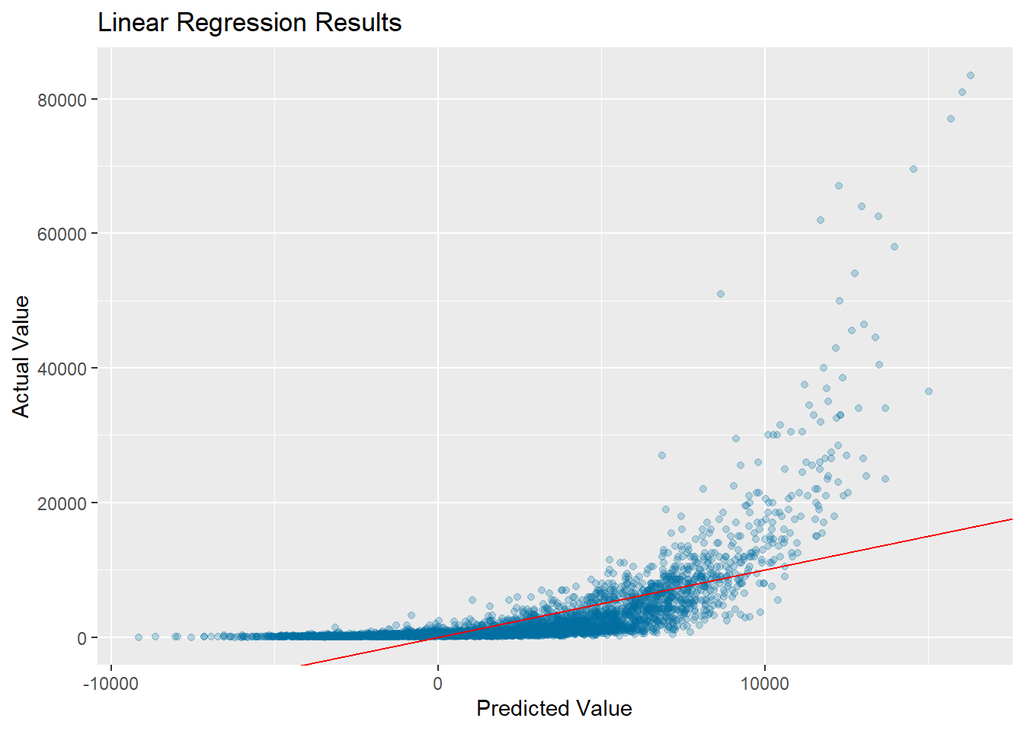

```r
fifa_results_lm %>%
ggplot(mapping = aes(x = .pred, y = Value)) +
  geom_point(color = '#006EA1', alpha = 0.25) +
  geom_abline(intercept = 0, slope = 1, color = 'red') +
  labs(title = 'Linear Regression Results',
       x = 'Predicted Value',
       y = 'Actual Value')
```

It is now observed that this type of modeling would be only beneficial regarding values under 20000. The reason is that the Values are not normally distributed, thus we can not consider this model very accurate.

# Model 2 & 3

KNN and Decision tree

```r
#Now we will test other models as the above model showed very poor results
#Create knn and decision tree spec

# we already have train & test sets
fifaRecipe <- fifa_train %>%
  recipe(Value ~ .) %>%
  step_center(all_numeric(),-all_outcomes()) %>%
  step_scale(all_numeric(),-all_outcomes()) %>%
  prep()

fifa_train_proc <- bake(fifaRecipe, new_data = fifa_train)
fiftest_proc <- bake(fifaRecipe, new_data = fifa_test)


knn_spec <- nearest_neighbor() %>%
  set_engine("kknn") %>%
  set_mode("regression")

knn_fit <- knn_spec %>%
  fit(Value ~ .,
      data=fifa_train_proc)

knn_fit
```

```
## parsnip model object
##
## Fit time:  5s
##
## Call:
## kknn::train.kknn(formula = Value ~ ., data = data, ks = min_rows(5,     data, 5))
##
## Type of response variable: continuous
## minimal mean absolute error: 898.3538
## Minimal mean squared error: 6844661
## Best kernel: optimal
## Best k: 5
```

```r
tree_spec <- decision_tree() %>%
  set_engine("rpart") %>%
  set_mode("regression") %>%
  translate()

tree_fit <- tree_spec %>%
  fit(Value ~ .,
      data=fifa_train)


tree_fit
```

```
## parsnip model object
##
## Fit time:  431ms
## n= 13432
##
## node), split, n, deviance, yval
##       * denotes terminal node
##
##  1) root 13432 433304400000  2454.7160
##    2) Reactions< 78.5 13030 123790300000  1820.4270
##      4) BallControl< 75.5 12290  53774200000  1366.7390
##        8) Reactions< 68.5 10262  12384120000   838.9924 *
##        9) Reactions>=68.5 2028  24069340000  4037.2190
##         18) StandingTackle< 77.5 1853  15058090000  3555.3890 *
##         19) StandingTackle>=77.5 175   4025922000  9139.1140 *
##      5) BallControl>=75.5 740  25472950000  9355.3380
##       10) BallControl< 86.5 731  16915820000  9033.4470 *
##       11) BallControl>=86.5 9   2329500000 35500.0000 *
##    3) Reactions>=78.5 402 134355100000 23013.8700
##      6) Reactions< 85.5 363  60190130000 19348.6900
##       12) BallControl< 82.5 255  28972530000 15496.3700
##         24) StandingTackle< 83.5 215  15590230000 13056.1600 *
##         25) StandingTackle>=83.5 40   5220744000 28612.5000 *
##       13) BallControl>=82.5 108  18498170000 28444.4400 *
##      7) Reactions>=85.5 39  23900860000 57128.2100
##       14) Curve< 82.5 29   8217241000 47017.2400 *
##       15) Curve>=82.5 10   4121225000 86450.0000 *
```

```r
#test Tree - rpart


set.seed(1234)
validation_splits <- vfold_cv(fifa_train,v=5)

kn_wf <- workflow() %>%
  add_recipe(fifaRecipe) %>%
  add_model(knn_spec)

knn_res <- fit_resamples(kn_wf,
  validation_splits ,
  control=control_resamples(save_pred = TRUE)
)

knn_res %>%
  collect_metrics()
```

```
## # A tibble: 2 x 6
##   .metric .estimator     mean     n std_err .config
##   <chr>   <chr>         <dbl> <int>   <dbl> <chr>
## 1 rmse    standard   2630.        5 53.7    Preprocessor1_Model1
## 2 rsq     standard      0.798     5  0.0107 Preprocessor1_Model1
```

```r
#test Tree - rpart
tree_wf <- workflow() %>%
  add_recipe(fifa_rec) %>%
  add_model(tree_spec)

tree_res <- fit_resamples(tree_wf,
                         fifa_folds ,
                         control=control_resamples(save_pred = TRUE)
)

tree_res %>%
  collect_metrics()
```

```
## # A tibble: 2 x 6
##   .metric .estimator     mean     n  std_err .config
##   <chr>   <chr>         <dbl> <int>    <dbl> <chr>
## 1 rmse    standard   2998.       10 111.     Preprocessor1_Model1
## 2 rsq     standard      0.720    10   0.0167 Preprocessor1_Model1
```

```r
tree_last_fit <- tree_wf %>%
    last_fit(data_split)

tree_last_fit %>% collect_metrics()
```

```
## # A tibble: 2 x 4
##   .metric .estimator .estimate .config
##   <chr>   <chr>          <dbl> <chr>
## 1 rmse    standard    3031.    Preprocessor1_Model1
## 2 rsq     standard       0.698 Preprocessor1_Model1
```

The top result for predicting value appears to be the k nearest neighbor algorithm, thus we will create a full model based on that.

```r
fifa_knn_wf <- workflow() %>%
  add_recipe(fifaRecipe) %>%
  add_model(knn_spec) %>%
  fit(fifa_train)

fifa_knn_wf
```

```
## == Workflow [trained] ==========================================================
## Preprocessor: Recipe
## Model: nearest_neighbor()
##
## -- Preprocessor ----------------------------------------------------------------
## 2 Recipe Steps
##
## * step_center()
## * step_scale()
##
## -- Model -----------------------------------------------------------------------
##
## Call:
## kknn::train.kknn(formula = ..y ~ ., data = data, ks = min_rows(5,     data, 5))
##
## Type of response variable: continuous
## minimal mean absolute error: 898.3538
## Minimal mean squared error: 6844661
## Best kernel: optimal
## Best k: 5
```

```r
fifa_knn_wf_pred <- fifa_knn_wf %>%
  predict(fifa_train) %>%
  bind_cols(fifa_train)

fifa_knn_wf_pred %>%
  select(Value, .pred) %>%
  glimpse()
```

```
## Rows: 13,432
## Columns: 2
## $ Value <dbl> 110500, 118500, 72000, 102000, 93000, 80000, 51000, 68000, 77000~
## $ .pred <dbl> 107308.77, 107144.25, 50871.39, 74667.58, 90861.22, 70544.71, 38~
```

```r
fifa_knn_wf_pred %>%
  metrics(truth = Value, estimate = .pred)
```

```
## # A tibble: 3 x 3
##   .metric .estimator .estimate
##   <chr>   <chr>          <dbl>
## 1 rmse    standard    1292.
## 2 rsq     standard       0.959
## 3 mae     standard     447.
```

```r
fifa_knn_wf %>%
  predict(fifa_test) %>%
  bind_cols(fifa_test) %>%
  metrics(truth = Value, estimate = .pred)
```

```
## # A tibble: 3 x 3
##   .metric .estimator .estimate
##   <chr>   <chr>          <dbl>
## 1 rmse    standard    2541.
## 2 rsq     standard       0.805
## 3 mae     standard     906.
```

```r
knn_last_fit <- fifa_knn_wf %>%
    last_fit(data_split)
```

```
## ! train/test split: preprocessor 1/1, model 1/1 (predictions): Unknown columns: `(Intercept)`
```

```r
knn_last_fit %>% collect_metrics()
```

```
## # A tibble: 2 x 4
##   .metric .estimator .estimate .config
##   <chr>   <chr>          <dbl> <chr>
## 1 rmse    standard    2541.    Preprocessor1_Model1
## 2 rsq     standard       0.805 Preprocessor1_Model1
```

Model 4

# Random Forest

We have already split our data into training, test, and cross validation sets as well as trained our feature engineering recipe, fifa_rec. These can be reused in our random forest workflow.

## Model

```r
rf_model <- rand_forest() %>%
  set_engine("ranger",
             num.threads = parallel::detectCores(),
             importance = "permutation",
             verbose = TRUE) %>%
  set_mode("regression") %>%
  set_args(trees = 1000)


rf_model
```

```
## Random Forest Model Specification (regression)
##
## Main Arguments:
##   trees = 1000
##
## Engine-Specific Arguments:
##   num.threads = parallel::detectCores()
##   importance = permutation
##   verbose = TRUE
##
## Computational engine: ranger
```

## Work flow

Next, we combine our model and recipe into a workflow to easily manage the model-building process.

```r
rf_workflow <- workflow() %>%
               add_model(rf_model) %>%
               add_recipe(fifa_rec)
```

## Fit the model

```r
set.seed(101)

fit_rf <- fit_resamples(
  rf_workflow,
  fifa_folds,
  metrics = metric_set(rmse, rsq),
  control = control_resamples(verbose = TRUE,
                              save_pred = TRUE,
                              extract = function(x) x)
)
```

```r
rf_last_fit <- rf_workflow %>%
    last_fit(data_split)

rf_last_fit %>% collect_metrics()
```

```
## # A tibble: 2 x 4
##   .metric .estimator .estimate .config
##   <chr>   <chr>          <dbl> <chr>
## 1 rmse    standard    1706.    Preprocessor1_Model1
## 2 rsq     standard       0.914 Preprocessor1_Model1
```

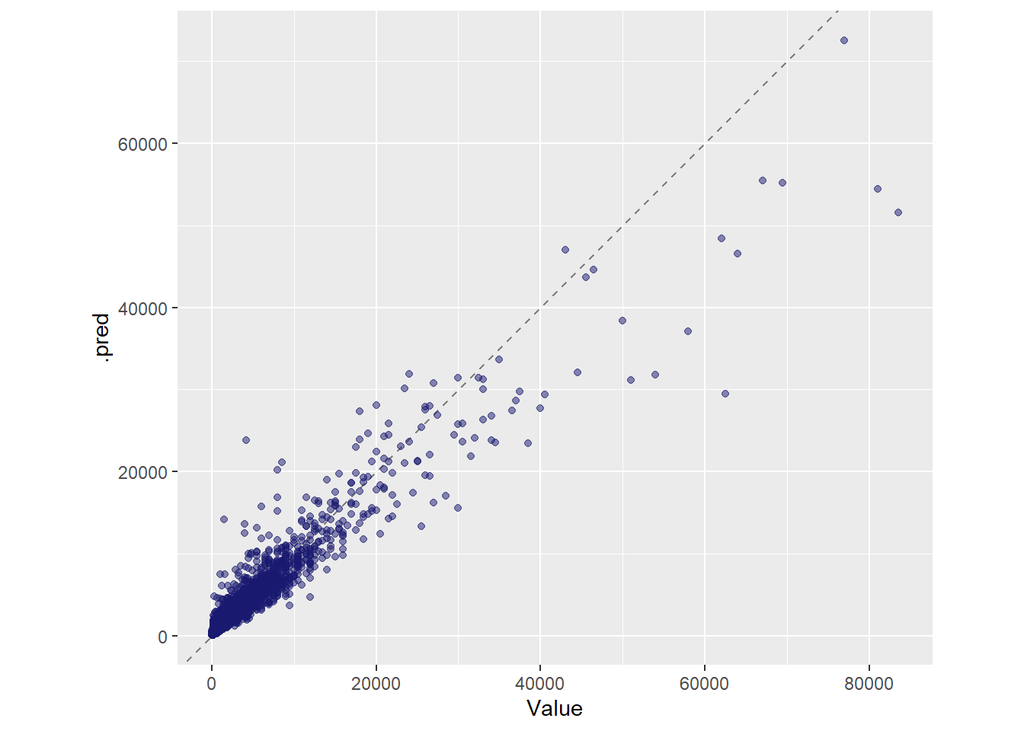

```r
collect_predictions(rf_last_fit) %>%
  ggplot(aes(Value, .pred)) +
  geom_abline(lty = 2, color = "gray50") +
  geom_point(alpha = 0.5, color = "midnightblue") +
  coord_fixed()
```

```r
collect_metrics(rf_last_fit) %>%
  bind_rows(collect_metrics(knn_last_fit)) %>%
  bind_rows(collect_metrics(tree_last_fit)) %>%
  bind_rows(collect_metrics(fifa_fit_lm)) %>%
  filter(.metric == "rmse") %>%
  mutate(model = c("RF", "Knn", "DT","LM")) %>%
  select(model, everything())
```

```
## # A tibble: 4 x 5
##   model .metric .estimator .estimate .config
##   <chr> <chr>   <chr>          <dbl> <chr>
## 1 RF    rmse    standard       1706. Preprocessor1_Model1
## 2 Knn   rmse    standard       2541. Preprocessor1_Model1
## 3 DT    rmse    standard       3031. Preprocessor1_Model1
## 4 LM    rmse    standard       4255. Preprocessor1_Model1
```

After Modeling the dataset, in the next part we are going to have another approach regarding making models. We want to improve the accuracy of models by considering Overall variable. In the following parts, we carry on the same models but with different variables as follow.

PART 3

- predicting player’s market `Value`
- Model 1

# KNN & Random Forest with only Overall, Composure, age, height & weight

Since we already calculated Overall ratings for each player, in this part we build our models only based on that and the remaining variables. In other words, we only consider Overall, Age, Height, Weight and Composure to predict the target variable, *Value*. For this part we only implement models of KNN & Random Forest since they show better results comparing to other models.

```r
fifa_model2 <- baseDS %>% select(Age, Weight, Height, Composure, Overall, Value)

set.seed(42)

data_split2 <- initial_split(fifa_model2, strata = Value, prop = 0.75)

fifa_train2 <- training(data_split2)
fifa_test2 <- testing(data_split2)

fifa_rec2 <- fifa_train2 %>%
  recipe(Value ~ . ) %>%
  step_normalize(all_predictors())


set.seed(12)

fifa_folds2 <-
 vfold_cv(fifa_train2,
          strata = Value)
```

KNN

```r
#Now we will test other models as the above model showed very poor results
#Create knn and decision tree spec

# we already have train & test sets
fifaRecipe2 <- fifa_train2 %>%
  recipe(Value ~ .) %>%
  step_center(all_numeric(),-all_outcomes()) %>%
  step_scale(all_numeric(),-all_outcomes()) %>%
  prep()

fifa_train_proc2 <- bake(fifaRecipe2, new_data = fifa_train2)
fiftest_proc2 <- bake(fifaRecipe2, new_data = fifa_test2)


knn_spec2 <- nearest_neighbor() %>%
  set_engine("kknn") %>%
  set_mode("regression")

knn_fit2 <- knn_spec2 %>%
  fit(Value ~ .,
      data=fifa_train_proc2)

knn_fit2
```

```
## parsnip model object
##
## Fit time:  2.1s
##
## Call:
## kknn::train.kknn(formula = Value ~ ., data = data, ks = min_rows(5,     data, 5))
##
## Type of response variable: continuous
## minimal mean absolute error: 887.2791
## Minimal mean squared error: 5996860
## Best kernel: optimal
## Best k: 5
```

```r
fifa_knn_wf2 <- workflow() %>%
  add_recipe(fifaRecipe2) %>%
  add_model(knn_spec2) %>%
  fit(fifa_train2)

fifa_knn_wf2
```

```
## == Workflow [trained] ==========================================================
## Preprocessor: Recipe
## Model: nearest_neighbor()
##
## -- Preprocessor ----------------------------------------------------------------
## 2 Recipe Steps
##
## * step_center()
## * step_scale()
##
## -- Model -----------------------------------------------------------------------
##
## Call:
## kknn::train.kknn(formula = ..y ~ ., data = data, ks = min_rows(5,     data, 5))
##
## Type of response variable: continuous
## minimal mean absolute error: 887.2791
## Minimal mean squared error: 5996860
## Best kernel: optimal
## Best k: 5
```

```r
fifa_knn_wf_pred2 <- fifa_knn_wf2 %>%
  predict(fifa_train2) %>%
  bind_cols(fifa_train2)

fifa_knn_wf_pred2 %>%
  select(Value, .pred) %>%
  glimpse()
```

```
## Rows: 13,432
## Columns: 2
## $ Value <dbl> 110500, 118500, 72000, 102000, 93000, 80000, 51000, 68000, 77000~
## $ .pred <dbl> 90629.92, 97828.27, 47523.81, 71003.46, 75972.80, 63738.66, 5043~
```

```r
fifa_knn_wf_pred2 %>%
  metrics(truth = Value, estimate = .pred)
```

```
## # A tibble: 3 x 3
##   .metric .estimator .estimate
##   <chr>   <chr>          <dbl>
## 1 rmse    standard    1396.
## 2 rsq     standard       0.945
## 3 mae     standard     508.
```

```r
fifa_knn_wf2 %>%
  predict(fifa_test2) %>%
  bind_cols(fifa_test2) %>%
  metrics(truth = Value, estimate = .pred)
```

```
## # A tibble: 3 x 3
##   .metric .estimator .estimate
##   <chr>   <chr>          <dbl>
## 1 rmse    standard    2301.
## 2 rsq     standard       0.826
## 3 mae     standard     869.
```

```r
knn_last_fit2 <- fifa_knn_wf2 %>%
    last_fit(data_split2)

knn_last_fit2 %>% collect_metrics()
```

```
## # A tibble: 2 x 4
##   .metric .estimator .estimate .config
##   <chr>   <chr>          <dbl> <chr>
## 1 rmse    standard    2301.    Preprocessor1_Model1
## 2 rsq     standard       0.826 Preprocessor1_Model1
```

# Random Forest

```r
rf_model2 <- rand_forest() %>%
  set_engine("ranger",
             num.threads = parallel::detectCores(),
             importance = "permutation",
             verbose = TRUE) %>%
  set_mode("regression") %>%
  set_args(trees = 1000)
```

```r
rf_workflow2 <- workflow() %>%
               add_model(rf_model2) %>%
               add_recipe(fifa_rec2)
```